# TBATS

Time Series

TBATS for Time Series Data

Yeongeun Jeon , Jung In Seo  
09-07-2021

- Data 출처 : [Data Mining for Business Analytics](https://www.dataminingbook.com/book/r-edition)에서 사용한 미국 철도 회사 “Amtrak”에서 수집한 1991년 1월~2004년 3월까지 매달 환승 고객 수

# **Introduction**

- TBATS 모형
  - T : Trigonometric seasonality
    - 퓨리에 항(Fourier Series) 기반
  - B : Box-Cox transformation
  - A : ARIMA errors
  - T : Trend (possibly damped)
  - S : Seasonal components
- TBATS 모형은 `광범위한 계절 패턴 변동`과 관련된 문제를 극복하고 `상관성이 있는 오차`를 처리하기 위해 `지수 평활(Exponential Smoothing)`을 사용한 수정된 상태공간 모형으로 [De Livera et al. (2011)](https://robjhyndman.com/papers/ComplexSeasonality.pdf)이 제안하였다.
- 게다가 비선형성(Nonlinearity)에 관련된 문제를 해결하기 위해 Box-Cox 변환도 고려되었다.
- TBATS 모형은 `복잡한 계절성`을 가진 시계열 데이터를 분석하는 데 유용하다.
  - 복잡한 계절성의 예 : 다중 계절성(Multiple Seasonal Pattern), Non-integer Seasonality, Non-nested Seasonality and Large-period Seasonality 등
- TBATS 모형은 계절성이 시간에 따라 느리게 변할 수 있다는 점에서 Dynamic Harmonic Regression과 다르다.
  - 즉, 시간이 지남에 따라 계절성이 천천히 변화할 수 있다는 장점이 있다.
- 하지만, 주기가 긴 시계열을 추정하는데 느릴 수 있다는 단점이 있다.

# **Application**

- Ridership on Amtrak Trains(미국 철도 회사 “Amtrak”에서 수집한 1991년 1월~2004년 3월까지 매달 환승 고객 수) 예제를 이용하여 TBATS 모형이 실제 데이터에 어떻게 적용되는지 설명한다.

## **Data 불러오기**

```
pacman::p_load("dplyr", "forecast", "parallel")

# In Mac
# guess_encoding("Amtrak.csv")
# Amtrak.data <- read.csv("Amtrak.csv", fileEncoding="EUC-KR")

Amtrak.data  <- read.csv("C:/Users/User/Desktop/Amtrak.csv")
ridership.ts <- ts(Amtrak.data$Ridership, start=c(1991,1), end=c(2004,3), freq=12)
```

## **Data 분할**

```
train.ts  <- window(ridership.ts,start=c(1991,1), end=c(2001,3))   # Training Data
test.ts   <- window(ridership.ts,start=c(2001,4))                  # Test Data
n.test    <- length(test.ts)
```

## **모형 적합**

- `forecast` package에 있는 `tbats()`를 이용하여 모형을 적합시킬 수 있다. 자세한 옵션은 [여기](https://www.rdocumentation.org/packages/forecast/versions/8.15/topics/tbats)를 참조한다.

```
tbats(
  y,
  use.box.cox = NULL,
  use.trend = NULL,
  use.damped.trend = NULL,
  seasonal.periods = NULL,
  use.arma.errors = TRUE,
  use.parallel = length(y) > 1000,
  num.cores = 2,
  bc.lower = 0,
  bc.upper = 1,
  biasadj = FALSE,
  model = NULL,
  ...
)
```

- y : 시계열 데이터
- use.box.cox : Box-Cox 변환 사용 여부로 NULL이면 둘 다 시도되고 AIC로 최적 적합을 선택
- use.trend : 추세 포함 여부로 NULL이면 둘 다 시도되고 AIC로 최적 적합을 선택
- use.damped.trend : 추세에 damping parameter 포함 여부로 NULL이면 둘 다 시도되고 AIC로 최적 적합을 선택
- seasonal.periods : y가 수치형일 경우, 명시되는 계절 기간
- use.arma.errors : ARIMA 오차항 사용 여부
- use.parallel : 병렬 처리 사용 여부
- num.cores : 코어 수
- bc.lower : Box-Cox 변환에 대한 최소값
- bc.upper : Box-Cox 변환에 대한 최대값
- biasadj : Box-Cox 변환에 수정된 역변환 평균을 사용 여부로 TRUE인 경우 점 예측값과 적합치는 평균 예측값,그렇지 않으면 예측 밀도의 중위수로 간주

```
cl <- parallel::makeCluster(detectCores(), setup_timeout = 0.5)
TBATS.fit <- train.ts %>%
  tbats(use.box.cox = FALSE,
        use.trend = TRUE,
        use.damped.trend = TRUE,
        use.parallel = TRUE,
        num.cores = cl)

summary(TBATS.fit)
```

```
                  Length Class  Mode
lambda               0   -none- NULL
alpha                1   -none- numeric
beta                 1   -none- numeric
damping.parameter    1   -none- numeric
gamma.one.values     1   -none- numeric
gamma.two.values     1   -none- numeric
ar.coefficients      0   -none- NULL
ma.coefficients      0   -none- NULL
likelihood           1   -none- numeric
optim.return.code    1   -none- numeric
variance             1   -none- numeric
AIC                  1   -none- numeric
parameters           2   -none- list
seed.states         12   -none- numeric
fitted.values      123   ts     numeric
errors             123   ts     numeric
x                 1476   -none- numeric
seasonal.periods     1   -none- numeric
k.vector             1   -none- numeric
y                  123   ts     numeric
p                    1   -none- numeric
q                    1   -none- numeric
call                 7   -none- call
series               1   -none- character
method               1   -none- character
```

## **예측**

```
TBATS.forecast <- forecast(TBATS.fit, h=n.test)
TBATS.forecast$mean
```

```
          Jan      Feb      Mar      Apr      May      Jun      Jul
2001                            1978.995 2028.484 1959.201 2089.790
2002 1721.923 1658.583 1979.689 1966.634 2018.589 1951.281 2083.449
2003 1720.255 1657.248 1978.620 1965.779 2017.904 1950.732 2083.010
2004 1720.140 1657.155 1978.546
          Aug      Sep      Oct      Nov      Dec
2001 2116.995 1814.845 1914.140 1924.798 1938.481
2002 2111.919 1810.782 1910.888 1922.195 1936.397
2003 2111.568 1810.501 1910.663 1922.015 1936.252
2004
```

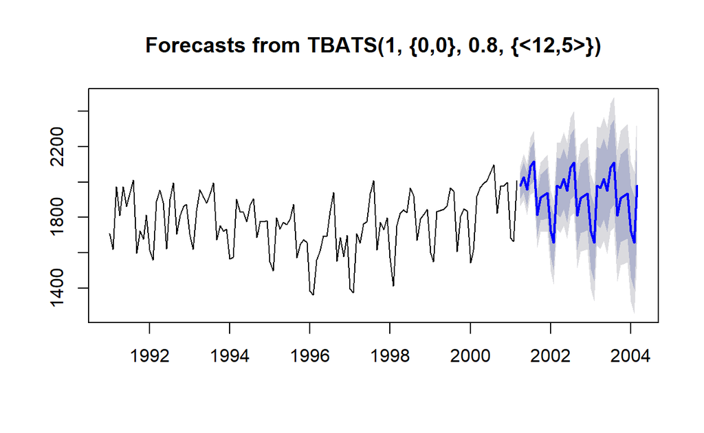

```
plot(TBATS.forecast)
```

```
accuracy(c(TBATS.forecast$mean), test.ts)
```

```
               ME    RMSE      MAE      MPE    MAPE     ACF1
Test set 69.36452 103.114 88.31896 3.379683 4.42057 0.556916
         Theil's U
Test set 0.5999032
```